# Multiple Correspondence Analysis

Dataset medkokeilu

### 1. Study of the outliers

The analysis of the graphs does not detect any outlier.

### 2. Inertia distribution

The inertia of the first dimensions shows if there are strong relationships between variables and suggests the number of dimensions that should be studied.

The first two dimensions of MCA express **27.05%** of the total dataset inertia ; that means that 27.05% of the individuals (or variables) cloud total variability is explained by the plane. This is a small percentage and the first plane just represents a part of the data variability. This value is greater than the reference value that equals **23.4%**, the variability explained by this plane is thus significant (the reference value is the 0.95-quantile of the inertia percentages distribution obtained by simulating 327 data tables of equivalent size on the basis of a uniform distribution).

From these observations, it is interesting to consider the next dimensions which also express a high percentage of the total inertia.

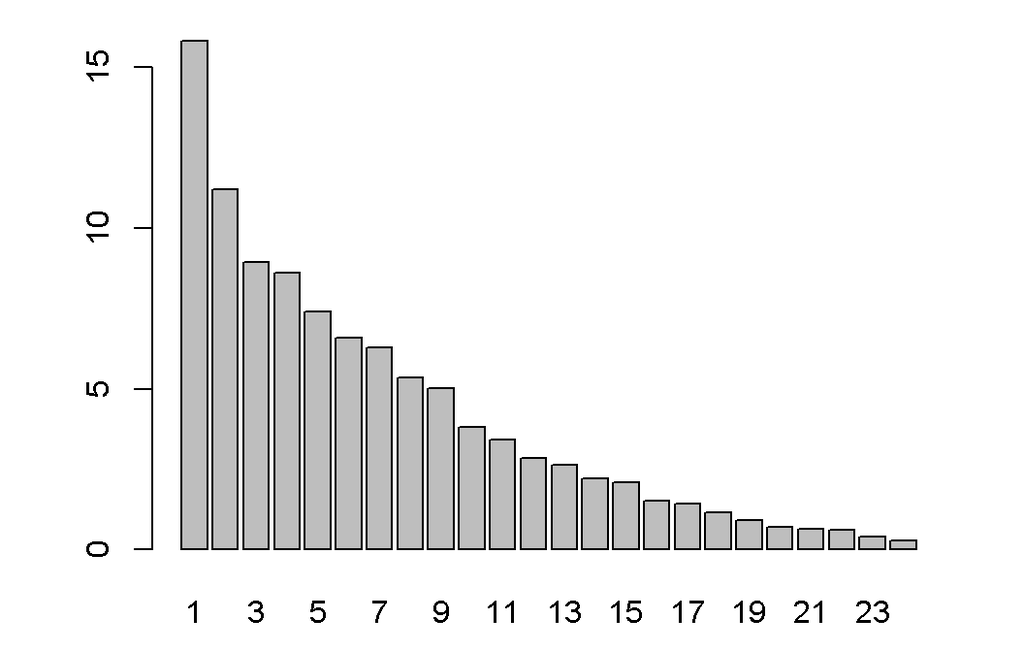

**Figure 2 - Decomposition of the total inertia on the components of the MCA**

An estimation of the right number of axis to interpret suggests to restrict the analysis to the description of the first 2 axis. These axis present an amount of inertia greater than those obtained by the 0.95-quantile of random distributions (27.05% against 23.4%). This observation suggests that only these axis are carrying a real information. As a consequence, the description will stand to these axis.

### 3. Description of the plane 1:2

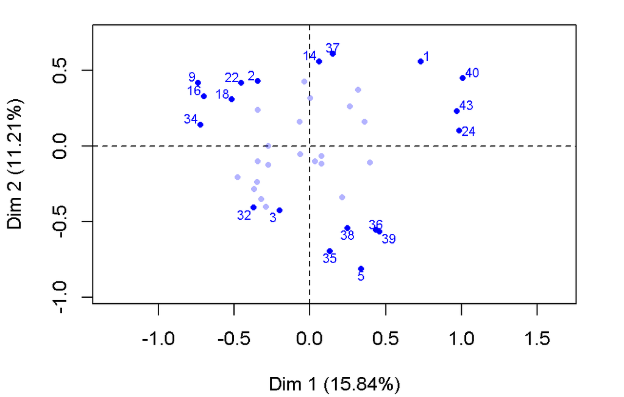

**Figure 3.1 - Individuals factor map (MCA)** *The labeled individuals are those with the higher contribution to the plane construction.*

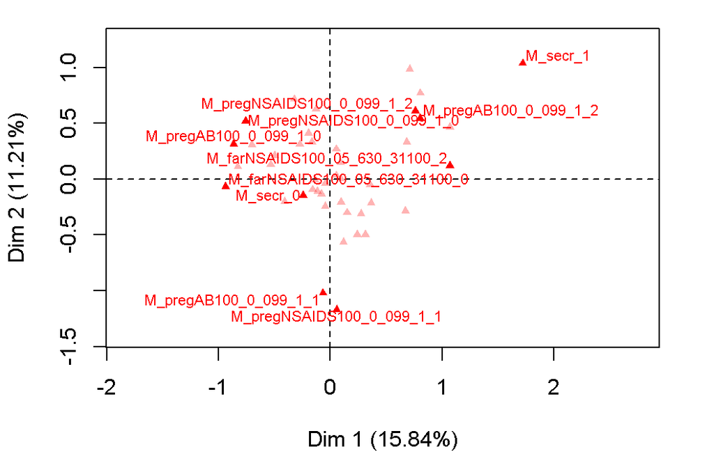

**Figure 3.2 - Variables factor map (MCA)** *The labeled variables are those the best shown on the plane.*

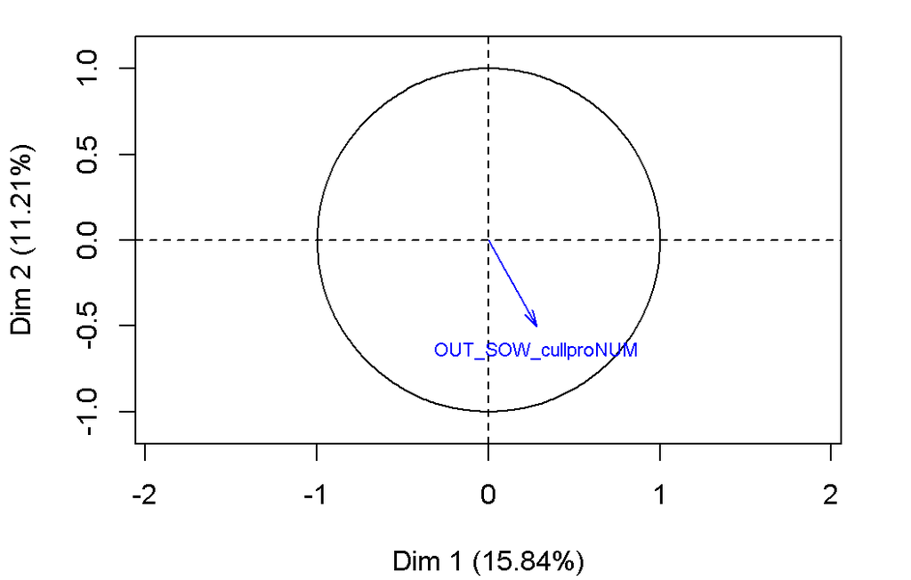

**Figure 3.3 - Quantitative factor map (MCA)** *The labeled variables are those the best shown on the plane.*

The group in which the individuals *40*, *24*, *43* and *1* stand (characterized by a positive coordinate on the axis) is sharing :

- high frequency for the factors *M_secr=M_secr_1*, *M_pregNSAIDS100_0_099_1=M_pregNSAIDS100_0_099_1_2*, *M_pregAB100_0_099_1=M_pregAB100_0_099_1_2*, *M_injury=M_injury_1* and *M_farAB100_05_510_10=M_farAB100_05_510_10_2* (factors are sorted from the most common).
- low frequency for the factors *M_secr=M_secr_0* and *M_injury=M_injury_0* (factors are sorted from the rarest).

The **dimension 2** opposes individuals such as *9*, *40*, *24*, *43*, *16*, *1*, *34*, *18*, *22* and *14* (to the top of the graph, characterized by a strongly positive coordinate on the axis) to individuals such as *5*, *36*, *39*, *35* and *38* (to the bottom of the graph, characterized by a strongly negative coordinate on the axis).

The group in which the individuals *9*, *16*, *34*, *18*, *22* and *14* stand (characterized by a positive coordinate on the axis) is sharing :

- high frequency for the factors *M_farAB100_05_510_10=M_farAB100_05_510_10_0*, *M_rOX=M_rOX_0*, *M_pregAB100_0_099_1=M_pregAB100_0_099_1_0*, *M_pregNSAIDS100_0_099_1=M_pregNSAIDS100_0_099_1_0*, *M_induction_0never_1sometimes=M_induction_0never_1sometimes_0*, *OUT_SOW_totrem_dic=OUT_SOW_totrem_dic_0*, *M_routine_0no_1yes=M_routine_0no_1yes_0*, *M_farNSAIDS100_05_630_31100=M_farNSAIDS100_05_630_31100_0*, *OUT_SOW_cull_dic=OUT_SOW_cull_dic_0* and *OUT_SOW_mort_dic=OUT_SOW_mort_dic_0* (factors are sorted from the most common).
- low frequency for the factors *M_induction_0never_1sometimes=M_induction_0never_1sometimes_1*, *M_rOX=M_rOX_1*, *OUT_SOW_totrem_dic=OUT_SOW_totrem_dic_1*, *M_routine_0no_1yes=M_routine_0no_1yes_1*, *OUT_SOW_cull_dic=OUT_SOW_cull_dic_1*, *M_farNSAIDS100_05_630_31100=M_farNSAIDS100_05_630_31100_2*, *OUT_SOW_mort_dic=OUT_SOW_mort_dic_1* and *M_pregNSAIDS100_0_099_1=M_pregNSAIDS100_0_099_1_1* (factors are sorted from the rarest).

The group in which the individuals *40*, *24*, *43* and *1* stand (characterized by a positive coordinate on the axis) is sharing :

- high frequency for the factors *M_secr=M_secr_1*, *M_pregNSAIDS100_0_099_1=M_pregNSAIDS100_0_099_1_2*, *M_pregAB100_0_099_1=M_pregAB100_0_099_1_2*, *M_injury=M_injury_1* and *M_farAB100_05_510_10=M_farAB100_05_510_10_2* (factors are sorted from the most common).
- low frequency for the factors *M_secr=M_secr_0* and *M_injury=M_injury_0* (factors are sorted from the rarest).

The group in which the individuals *5*, *36*, *39*, *35* and *38* stand (characterized by a negative coordinate on the axis) is sharing :

- high frequency for the factors *M_pregNSAIDS100_0_099_1=M_pregNSAIDS100_0_099_1_1*, *M_farAB100_05_510_10=M_farAB100_05_510_10_1*, *M_pregAB100_0_099_1=M_pregAB100_0_099_1_1*, *OUT_SOW_totrem_dic=OUT_SOW_totrem_dic_1* and *OUT_SOW_cull_dic=OUT_SOW_cull_dic_1* (factors are sorted from the most common).
- low frequency for the factors *OUT_SOW_totrem_dic=OUT_SOW_totrem_dic_0*, *M_farAB100_05_510_10=M_farAB100_05_510_10_0* and *OUT_SOW_cull_dic=OUT_SOW_cull_dic_0* (factors are sorted from the rarest).

### 4. Classification

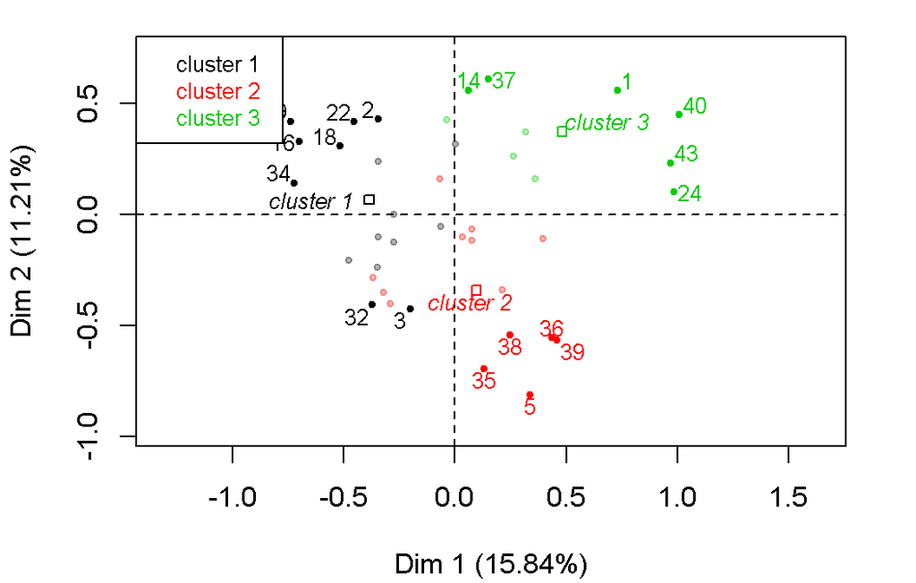

**Figure 4 - Ascending Hierarchical Classification of the individuals.** *The classification made on individuals reveals 3 clusters.*

- high frequency for the factors *M_pregNSAIDS100_0_099_1=M_pregNSAIDS100_0_099_1_0*, *M_farNSAIDS100_05_630_31100=M_farNSAIDS100_05_630_31100_0*, *M_pregAB100_0_099_1=M_pregAB100_0_099_1_0*, *M_routine_0no_1yes=M_routine_0no_1yes_0*, *M_injury=M_injury_0*, *M_rOX=M_rOX_0*, *M_farAB100_05_510_10=M_farAB100_05_510_10_0* and *M_anorex=M_anorex_0* (factors are sorted from the most common).
- low frequency for the factors *M_farNSAIDS100_05_630_31100=M_farNSAIDS100_05_630_31100_2*, *M_pregNSAIDS100_0_099_1=M_pregNSAIDS100_0_099_1_2*, *M_routine_0no_1yes=M_routine_0no_1yes_1*, *M_injury=M_injury_1*, *M_pregAB100_0_099_1=M_pregAB100_0_099_1_2*, *M_rOX=M_rOX_1* and *M_anorex=M_anorex_1* (factors are sorted from the rarest).

- high frequency for the factors *M_pregNSAIDS100_0_099_1=M_pregNSAIDS100_0_099_1_1*, *M_pregAB100_0_099_1=M_pregAB100_0_099_1_1*, *M_anorex=M_anorex_1* and *M_lame=M_lame_1* (factors are sorted from the most common).
- low frequency for the factors *M_anorex=M_anorex_0*, *M_pregNSAIDS100_0_099_1=M_pregNSAIDS100_0_099_1_0* and *M_lame=M_lame_0* (factors are sorted from the rarest).

- high frequency for the factors *M_pregAB100_0_099_1=M_pregAB100_0_099_1_2*, *M_pregNSAIDS100_0_099_1=M_pregNSAIDS100_0_099_1_2*, *M_secr=M_secr_1*, *M_farNSAIDS100_05_630_31100=M_farNSAIDS100_05_630_31100_2*, *M_routine_0no_1yes=M_routine_0no_1yes_1*, *M_injury=M_injury_1* and *OUT_SOW_totrem_dic=OUT_SOW_totrem_dic_0* (factors are sorted from the most common).
- low frequency for the factors *M_secr=M_secr_0*, *M_pregNSAIDS100_0_099_1=M_pregNSAIDS100_0_099_1_1*, *M_pregAB100_0_099_1=M_pregAB100_0_099_1_0*, *M_farNSAIDS100_05_630_31100=M_farNSAIDS100_05_630_31100_0*, *M_pregAB100_0_099_1=M_pregAB100_0_099_1_1*, *M_routine_0no_1yes=M_routine_0no_1yes_0*, *M_injury=M_injury_0* and *OUT_SOW_totrem_dic=OUT_SOW_totrem_dic_1* (factors are sorted from the rarest).

## Annexes

```r
res.hcpc$desc.var
```

```
$test.chi2
                                    p.value df
M_pregNSAIDS100_0_099_1     0.0000001795945  4
M_pregAB100_0_099_1         0.0000006296438  4
M_farNSAIDS100_05_630_31100 0.0001719506762  4
M_secr                      0.0001894418252  2
M_routine_0no_1yes          0.0066525495817  2
M_anorex                    0.0077615361341  2
M_injury                    0.0114200927579  2
M_farAB100_05_510_10        0.0366545231702  4
M_lame                      0.0397237333864  2
M_rOX                       0.0456239771813  2

$category
$category$`1`
                                                            Cla/Mod
M_pregNSAIDS100_0_099_1=M_pregNSAIDS100_0_099_1_0         85.714286
M_farNSAIDS100_05_630_31100=M_farNSAIDS100_05_630_31100_0 84.615385
M_pregAB100_0_099_1=M_pregAB100_0_099_1_0                 84.615385
M_routine_0no_1yes=M_routine_0no_1yes_0                   75.000000
M_injury=M_injury_0                                       56.000000
M_rOX=M_rOX_0                                             56.521739
M_farAB100_05_510_10=M_farAB100_05_510_10_0               57.142857
M_anorex=M_anorex_0                                       57.894737
M_anorex=M_anorex_1                                       23.809524
M_rOX=M_rOX_1                                             17.647059
M_pregAB100_0_099_1=M_pregAB100_0_099_1_2                 13.333333
M_injury=M_injury_1                                       13.333333
M_routine_0no_1yes=M_routine_0no_1yes_1                   25.000000
M_pregNSAIDS100_0_099_1=M_pregNSAIDS100_0_099_1_2          7.692308
M_farNSAIDS100_05_630_31100=M_farNSAIDS100_05_630_31100_2  0.000000
                                                          Mod/Cla Global
M_pregNSAIDS100_0_099_1=M_pregNSAIDS100_0_099_1_0           75.00   35.0
M_farNSAIDS100_05_630_31100=M_farNSAIDS100_05_630_31100_0   68.75   32.5
M_pregAB100_0_099_1=M_pregAB100_0_099_1_0                   68.75   32.5
M_routine_0no_1yes=M_routine_0no_1yes_0                     56.25   30.0
M_injury=M_injury_0                                         87.50   62.5
M_rOX=M_rOX_0                                               81.25   57.5
M_farAB100_05_510_10=M_farAB100_05_510_10_0                 75.00   52.5
M_anorex=M_anorex_0                                         68.75   47.5
```

[output cut: 120 more lines]

```
M_routine_0no_1yes=M_routine_0no_1yes_1                    2.420913
M_injury=M_injury_1                                        2.284918
OUT_SOW_totrem_dic=OUT_SOW_totrem_dic_0                    2.264883
OUT_SOW_totrem_dic=OUT_SOW_totrem_dic_1                   -2.264883
M_injury=M_injury_0                                       -2.284918
M_routine_0no_1yes=M_routine_0no_1yes_0                   -2.420913
M_pregAB100_0_099_1=M_pregAB100_0_099_1_1                 -2.420913
M_farNSAIDS100_05_630_31100=M_farNSAIDS100_05_630_31100_0 -2.577478
M_pregAB100_0_099_1=M_pregAB100_0_099_1_0                 -2.577478
M_pregNSAIDS100_0_099_1=M_pregNSAIDS100_0_099_1_1         -2.577478
M_secr=M_secr_0                                           -3.551547


attr(,"class")
[1] "catdes" "list "
```

**Figure 5 - List of variables characterizing the clusters of the classification.**